# The BC2S3 line pool as a denoiser, and the Zx.0090_P2 family

What the in-silico pool of each donor’s lines does in discovery, and how the six-donor test’s failure was narrowed down to two families (chr10, 2026-10-07)

Author

Fausto Rodríguez-Zapata

Published

October 7, 2026

Variant discovery runs CRISP per donor on its BC1 pools plus one in-silico pool of all its BC2S3 lines (math supplement, Section 4), then keeps a site only if that line pool shows an ALT read (the witness veto, Section 4.2), then step 4’s tiers (ALT in at least 2 BC1 pools, likelihood ratio, flags). RTIGER then infers each line’s ancestry at the donor’s tier-A sites. In the six-donor union test (`docs/runs/genotype_union_6donors_races_chr10.md`) two of the six donors failed: few sites and fragmented ancestry. This notebook records what the line pool does for the other four, and how the failure was traced to the two families rather than to the method or the sequencing.

## The data

Six mexicana donors on chr10: the four of the first test (Zx.0540_P3, Zx.0570_P2 races Durango and Nobogame, Zx.0550_P4, Zx.0580_P2) and two added for new races, Zx.0500_P2 (Mesa Central) and Zx.0090_P2 (Chalco). GENOTYPE runs: jobs 1134902 and 1146812. Independent reference: zealhmm’s RTIGER on the SNP50K panel (zealtiger `fit_rtiger_by_donor.R`: per donor accession, rigidity 8, ~49 thousand panel markers genome-wide, ~3.4 thousand on chr10), which covers the batch-1 lines of all six donors.

| Donor | Race | BC1 pools | Lines | Line plates |
| --- | --- | --- | --- | --- |
| Zx.0540_P3 | Durango | 5 | 40 batch-1 | BZea5, BZea6 |
| Zx.0550_P4 | Durango | 4 | 43 batch-1 | BZea5 |
| Zx.0570_P2 | Nobogame | 5 | 44 batch-1 | BZea8, BZea9 |
| Zx.0580_P2 | Nobogame | 5 | 50 batch-1 | BZea7, BZea8 |
| Zx.0500_P2 | Mesa Central | 5 | 11 batch-1 + 11 batch-2 | BZea4; BZeaV2_4 |
| Zx.0090_P2 | Chalco | 5 | 12 batch-1 + 11 batch-2 | BZea3, BZea4; BZeaV2_3 |

## 1. The line pool as a denoiser

### Discovery with and without the line pool

CRISP was also run on each donor’s BC1 pools alone (jobs 1148722, 1148870, 1149032), with the pipeline’s command and container. Markers for RTIGER from that run: biallelic SNPs in the low-copy ranges with ALT reads in at least 2 BC1 pools (step 4’s pool rule; no veto, no likelihood or flags); lines counted and RTIGER run as in the pipeline (job 1149090).

| Donor | CRISP, BC1 pools only | CRISP, BC1 pools + line pool | Kept by the veto | Tier A |
| --- | --- | --- | --- | --- |
| Zx.0540_P3 | 8,099 | 60,312 | 43,925 (73 %) | 32,750 |
| Zx.0570_P2 | 11,741 | 100,331 | 64,640 (64 %) | 48,251 |
| Zx.0550_P4 | 60,634 | 184,394 | 111,740 (61 %) | 85,952 |
| Zx.0580_P2 | 28,226 | 178,789 | 122,413 (68 %) | 82,601 |
| Zx.0500_P2 | 6,903 | 20,518 | 13,749 (67 %) | 9,060 |
| Zx.0090_P2 | 22,104 | 45,606 | 12,477 (27 %) | 7,482 |

### Ancestry from the three marker sets

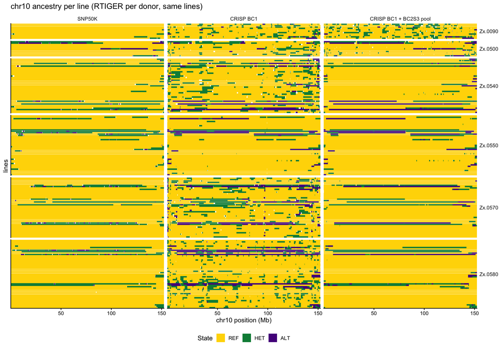

| donor | lines | donor segments per line (median, lines with any)_SNP50K | donor segments per line (median, lines with any)_CRISP BC1 | donor segments per line (median, lines with any)_CRISP BC1 + BC2S3 pool | lines with no introgression (< 2 %)_SNP50K | lines with no introgression (< 2 %)_CRISP BC1 | lines with no introgression (< 2 %)_CRISP BC1 + BC2S3 pool |
| --- | --- | --- | --- | --- | --- | --- | --- |
| Zx.0090 | 11 | 2.5 | 12.0 | 17 | 8 | 0 | 0 |
| Zx.0500 | 11 | 4.0 | 11.0 | 14 | 6 | 1 | 3 |
| Zx.0540 | 39 | 1.0 | 8.0 | 2 | 29 | 3 | 24 |
| Zx.0550 | 43 | 2.0 | 3.0 | 2 | 30 | 23 | 28 |
| Zx.0570 | 43 | 2.0 | 9.0 | 2 | 35 | 7 | 31 |
| Zx.0580 | 49 | 1.0 | 10.5 | 2 | 36 | 10 | 33 |

For the four good donors the line pool removes what the BC1 pools alone call but the lines do not support (false alleles, pool errors): the right column matches SNP50K, the middle one does not. That is the denoising the veto was meant to do at RTIGER’s input (user: “the BC2S3 pool works as a noise filter for most of the donors”). For the two problem donors neither marker set gives SNP50K’s picture.

## 2. Narrowing down the Zx.0090_P2 problem

Each step below ruled out a candidate.

**1. The calls are broken, the plants are not.** SNP50K RTIGER on the same batch-1 lines shows a normal BC2S3 pattern for both donors (table above: most lines without introgression on chr10, a few long segments); ours spreads short segments over every line. RTIGER is fitted per donor in both, so the difference is the markers, not the model.

**2. Not coverage.**

| donor | BC1 pools | BC1 coverage, summed | lines | line coverage, summed |
| --- | --- | --- | --- | --- |
| Zx.0540_P3 | 5 | 18.0 | 40 | 11.2 |
| Zx.0570_P2 | 5 | 18.2 | 44 | 15.6 |
| Zx.0550_P4 | 4 | 18.8 | 43 | 14.0 |
| Zx.0580_P2 | 5 | 20.9 | 50 | 20.5 |
| Zx.0090_P2 | 5 | 20.5 | 23 | 9.1 |
| Zx.0500_P2 | 5 | 16.9 | 22 | 8.9 |

The problem donors’ BC1 pools are as deep as the others’; they have half as many lines.

**3. Not the BC1 pools.** At each donor’s private tier-A sites (sites only that donor called among the six), every BC1 pool is highest at its own donor’s sites; the problem donors’ pools look like the others’. BC1-only CRISP finds 6,903 sites for Zx.0500_P2 against 8,099 for Zx.0540_P3.

| pools of | % non-REF reads at other donors’ private sites (mean) | % at own donor’s private sites |
| --- | --- | --- |
| Zx.0090_P2 | 8.4 | 24.7 |
| Zx.0500_P2 | 8.6 | 25.7 |
| Zx.0540_P3 | 15.2 | 27.5 |
| Zx.0550_P4 | 11.7 | 28.4 |
| Zx.0570_P2 | 12.0 | 26.7 |
| Zx.0580_P2 | 9.4 | 25.9 |

**4. The lines carry a background of their own donor’s alleles; B73 does not.**

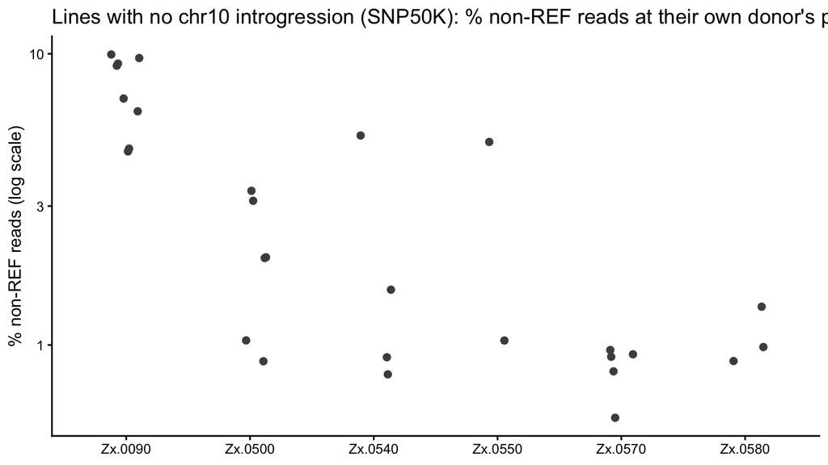

| group | % non-REF reads at Zx.0090_P2’s private sites |
| --- | --- |
| B73 WGS control | 0.08 |
| B73 checks, batch 2 | 0.07 |
| B73 checks, batch 1 | 0.68 |

**5. Not a sequencing batch or a plate.** Zx.0090_P2’s batch-1 lines (plate 3) and batch-2 lines (BZeaV2_3) carry the same background; they were sampled and sequenced separately. Most batch-1 B73 checks are clean (0.1-0.4 %); two are noisy (PN3_SID236 on plate 3, PN5_SID429 on plate 5), not a whole plate. The good donors’ lines on plates 5-9 are clean.

**6. Why SNP50K does not see it.** The panel’s markers are mostly not this donor’s alleles, so a few percent of the donor’s DNA shows at only some of them and stays near the error rate; our markers are exactly the donor’s alleles, and the veto selects those where the lines show ALT reads. The same reads look clean on panel markers and dirty on donor markers.

## 3. Interpretation

The problem follows the family, upstream of the sequencing: both batches, separate libraries, normal BC1 pools, B73 clean, the background specific to the donor’s own alleles. The contaminating material carries this donor’s alleles in much larger amount than a BC2S3 line: an earlier generation of the same family (BC1, BC2, BC2S1) or a highly introgressed sib ear. The user’s reading: a problem in the cross, or seed from the wrong ear in the planted seed packet. A wrong ear alone would give whole off-type plants (some lines clean genotypes of another family), not a background in every line; if each line sample is a bulk of seedlings (the pedigree has a `BC2S3-blk` stage for these families), a few off-type seeds in the packet put a fraction of off-type DNA into every bulk, and both batches drew from the same packets. Zx.0500_P2 shows the same at about a third of the dose.

## Open questions

- Field and seed records of these two families: whether their BC2S3 packets or plots were near or mixed with earlier-generation seed of the same donor; whether batch-2 samples are bulks too.
- A per-line background measure (% non-REF reads at the donor’s own sites where the line is B73) as a line QC before the in-silico pool and RTIGER, run over the whole population to see whether other families are affected.
- Whether the veto should act only at RTIGER’s input (where it denoises) and not cut discovery (`agent/notes_discovery_bc1_rescue_20261007.md`).
- CRISP models every pool with 12 haplotypes (`-p 12`), the line pool (22-50 lines) included.

## Sources

Scripts and logs in `agent/union6/` (discovery-step counts, veto gain, private-site counts in `identity/`, BC1-only lane in `bc1only_rtiger/`); SNP50K calls: zealhmm `data/zeal/rtiger_50K_calls.csv` (from zealtiger `fit_rtiger_by_donor.R`).